# Welcome to the

# NBIS Neural Nets & Deep Learning workshop

## Who are we?

| Claudio | Bengt | Christophe | Per |
| --- | --- | --- | --- |
| Marcin | Ashfaq | Malin |  |

# Who are you?

[figure not shown]

# Who are you?

[figure not shown]

# Who are you?

[figure not shown]

# Who are you?

[figure not shown]

# Who are you?

[figure not shown]

# Who are you?

[figure not shown]

## Course website

[https://uppsala.instructure.com/courses/47910](https://uppsala.instructure.com/courses/47910)

- Learning outcomes
- Prerequisties/preparations
- Discussions
- Schedule / Modules

## Feedback session on Friday

We are counting on your feedback!

- Does the schedule work the way it's laid out?
- What did you think of the lectures and labs?
- Too simple/hard?
- Write down one thing you liked and one you didn't at the end of each session, let us know at the end

## Practical issues

- Try to keep your **cameras on**, but **microphone muted**
- Lectures with many breaks
- Take lots of small breaks also when working with the exercises
- We will try to stick to the schedule, but it's only preliminary until it's happened
- If you have any questions during the lecture, feel free to unmute and ask. If you don't want to ask in the Zoom meeting, write the question in the chat or on slack

### So, this course is about Artificial Neural networks (Anns)

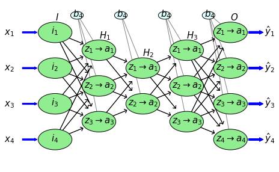

[figure not shown]

### .... What is that?

# AI vs ML vs ANN vs DL

[figure not shown]

(taken from https://medium.com/ai-in-plain-english/artificial-intelligence-vs-machine-learning-vs-deep-learning-whats-the-difference-dccce18efe7f)

#### AI -- Artificial Intelligence

- The science and engineering of creating intelligent machines

#### ML -- Machine learning

- Subset of AI
- Computer algorithms that learn/improve from experience

#### ANN -- Artificial Neural Networks

- Subset of ML
- Model of human neural networks
- Networks built up by artificial neurons

#### DL -- Deep Learning

- Subset of ANN (? -- depend on definition of ANN)
- ANN with more than one hidden layer

# Where does ANN come from?

## History

### First wave of ANN (funding)

- 1943 First model of biological neruon (McCulloch & Pitts)
- 1949 Hebbian Learning rules for ANN, (Donald Hebb)
- 1951 First ANN (Minsky)
- 1958 The *Perceptron* -- linear classification
- 1969 Limitations of the perceptron (Minsky & Papert)

[figure not shown]

(taken from https://www.sciencedirect.com/topics/neuroscience/perceptron)

[figure not shown]

(taken from https://news.cornell.edu/stories/2019/09/professors-perceptron-paved-way-ai-60-years-too-soon)

## History

### Second wave of ANN (funding)

- (1975 Back propagation algorithm (Werbos))
- 1986 Back propagation rediscovered and sigmoid activation -- ANNs in vogue again
- 1985-87 ANN conferences, societies started (IEEE, INNS)
- Vanishing gradient problem
- SVM outcompetes ANNs, ANNs survives in protein structure prediction (e.g., CASP)

[figure not shown]

(taken from https://www.kdnuggets.com/2019/01/backpropagation-algorithm-demystified.html)

[figure not shown]

(taken from https://predictioncenter.org)

## History

### Third wave of ANN (funding)

- GPUs and parallelization
- "Deep Learning" buzzword and performing well in contests
- 1997 Recursive Neural Nets. LSTMs (Smidhuber & Hochreiter)
- 2000 ReLU (Hahnloser et al.?)
- 2011 CNNs
- 2020 AlphaFold2 souvereign at CASP14
- ANNs are everywhere!

[figure not shown]

(taken from https://towardsdatascience.com/a-comprehensive-guide-to-convolutional-neural-networks-the-eli5-way-3bd2b1164a53)

## Applications -- general

Written and spoke language recognition

[figure not shown]

(taken from Mouret, Jean-Baptiste & Doncieux, Stéphane. (2008). Evolutionary Intelligence

Risk predictions

[figure not shown]

(taken from https://spectrum.ieee.org/computing/embedded-systems/bringing-big-neural-networks-to-selfdriving-cars-smartphones-and-drones)

## Applications -- general

Forecasting, weather, business

[figure not shown]

(taken from https://www.gjesm.net/article_23079.html)

Face recognition *and* generation

[figure not shown]

(taken from https://medium.com/syncedreview/gan-2-0-nvidias-hyperrealistic-face-generator-e3439d33ebaf)

## Applications -- Biosciences

Protein structure prediction

[figure not shown]

(taken from https://www.theverge.com/2020/12/1/21754310/deepmind-alphafold-ai-protein-folding-casp-competition)

Bioimaging diagnostics

[figure not shown]

(taken from https://peerj.com/articles/6201/)

## Applications -- Biosciences

Spatial transcriptomics

[figure not shown]

(taken from https://www.uu.se/en/news-media/press-releases/press-release/?id=5226&typ=pm&lang=en)